# Спецификация к Лабораторной работе №5 "Экстремум"

# (Вариант 22)

## Абстракция А0

### 1. Постановка задачи.

#### Задание:

Написать программу обработки одномерного массива в соответствии с условием.

#### Условие:

Для заданного массива $\{A_1, A_2, …, A_n\}$ определить наименьшее значение сумм $A_i + A_{i-1}$.

### 2. Уточненная постановка задачи.

Дан одномерный вещественный массив A из n элементов.

Найти $\displaystyle{\min_i(A_i + A_{i-1}), \ i \in \{2, ..., n\} }$.

### 3. Пример с иллюстрацией.

```
                    Лаб.5
==========================================================================================
Текстовый файл с элементами массива A: A_Lab5_4.txt
Текстовый файл с элементами массива A и минимальной суммой соседних элементов: AMIN_Lab5_4.txt
==========================================================================================
Массив A:
 101.5
212.6
-3.08
-15.876
-104.2
12.81
33.17
1.9
-564.22
371.4
178.23
-468.11
982.36
19.2
-908.1
-45.5
-22.345
342.6
825.33
-567.4
==========================================================================================
Минимальная сумма соседних элементов массива A: -953.6
```

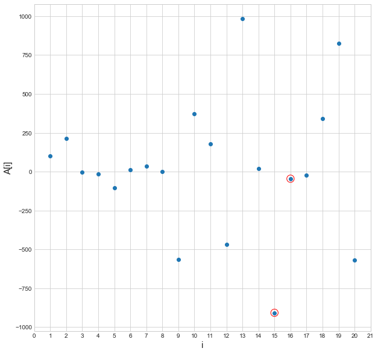

```python
import pylab
import numpy
%matplotlib inline
pylab.style.use('seaborn-whitegrid')

# A_Lab5_1.txt, A_Lab5_2.txt, A_Lab5_3.txt, A_Lab5_4.txt, A_Lab5_5.txt
# AMIN_Lab5_1.txt, AMIN_Lab5_2.txt, AMIN_Lab5_3.txt, AMIN_Lab5_4.txt, AMIN_Lab5_5.txt

print(20*' ' + 'Лаб.5\n' + 90*'=')

fin = str(input('Текстовый файл с элементами массива A: '))
fout = str(input('Текстовый файл с элементами массива A и минимальной суммой соседних элементов: '))

with open(fin, 'r') as f:
    A = [float(x) for x in f.readlines()]
n = len(A)
MIN = 10**10
MIN_ID = 10**5

print(90*'=' + '\n' + 'Массив A: \n', A[0])
for i in range(1, n):
    print(A[i])
    if (A[i] + A[i-1] < MIN):
        MIN = A[i] + A[i-1]
        MIN_ID = i

print(90*'=' + '\n' + 'Минимальная сумма соседних элементов массива A:', MIN)

with open(fout, 'w') as f:
    for i in range(0, n):
        f.write("{}\n".format(A[i]))
    f.write("{}".format(MIN))

pylab.figure(figsize=(10,10))
pylab.scatter(range(n), A)
pylab.scatter([MIN_ID - 1, MIN_ID], [A[MIN_ID - 1], A[MIN_ID]],
             s=150, facecolors='none', edgecolors='r')

pylab.xlabel('i', fontsize=15)
pylab.ylabel('A[i]', fontsize=15)
pylab.xticks(range(-1, n+1), range(n+2));
```

```python
print(A)
```

```
[101.5, 212.6, -3.08, -15.876, -104.2, 12.81, 33.17, 1.9, -564.22, 371.4, 178.23, -468.11, 982.36, 19.2, -908.1, -45.5, -22.345, 342.6, 825.33, -567.4]
```

```python
n
```

```
20
```

```python
MIN
```

```
-953.6
```

### 4. Таблица данных

| Класс | Имя | Описание (смысл, диапазон, точность) | Тип | Структура | Формат в/в |
| --- | --- | --- | --- | --- | --- |
| входные данные | fin | название текстового файла с элементами массива А | символ | строка | "+X.txt" |
| входные данные | fout | название текстового файла с элементами массива А | символ | строка | "+X.txt" |
| входные данные | A | вводимые из текстового файла числа | вещ | одномерный массив (20) | +XX.XX+ (:5:6) |
| выходные данные | MIN | выводимая в текстовый файл минимальная сумма соседних элементов массива | вещ | простая переменная | +XX.XX+ (:5:6) |
| промежуточные данные | PRE | предыдущий элемент для $A[i]$ | вещ | простая переменная | +XX.XX+ (:5:6) |
| промежуточные данные | i | индекс текущего элемента, 1≤i≤21 | цел | простая переменная | --- |

*! в Delphi выход из цикла с 1 до 20 с шагом +1 происходит при значении 21, из цикла с 20 до 1 – при 0*

### 5. Входная форма

- обр 1.1 Текстовый файл с элементами массива A: $<fin>$
- обр 1.2 Текстовый файл с элементами массива A и минимальной суммой соседних элементов: $<fout>$
- обр 2.1 Массив A:
- обр 2.2 $ < A[1] > \\ < A[2] > \\ … \\ < A[n] > $

### 6. Выходная форма

- обр 3 Лаб. 5
- обр 4.1 Текстовый файл с элементами массива A: $<fin>$
- обр 4.2 Текстовый файл с элементами массива A и минимальной суммой соседних элементов: $<fout>$
- обр 5.1 Массив A:
- обр 5.2 $ < A[1] > \\ < A[2] > \\ … \\ < A[n] > $
- обр 6 Минимальная сумма соседних элементов массива A: $< MIN >$

### 7. Аномалии

-

### 8. Функциональные тесты

| Исходные данные | - | - | Результаты | Тест |
| --- | --- | --- | --- | --- |
| fin | fout | A | MIN | № |
| A_Lab5_1.txt | AMIN_Lab5_1.txt | `[11, 20, -35, 100, -56, -71, -89, 90, 33, 25, 16, 67, 112, -107, 64, 38, 22, 45, -93]` | `-160` | 1 |
| - | - | - | - | - |
| A_Lab5_2.txt | AMIN_Lab5_2.txt | `[0, 0, 0, -1, -1, 0, 0, 0]` | `-2` | 2 |
| - | - | - | - | - |
| A_Lab5_3.txt | AMIN_Lab5_3.txt | `[10, 8, 6, 4, 2, 0, -1, -3, -5, -7, -9]` | `-16` | 3 |
| - | - | - | - | - |
| A_Lab5_4.txt | AMIN_Lab5_4.txt | `[101.5, 212.6, -3.08, -15.876, -104.2, 12.81, 33.17, 1.9, -564.22,` | `-953.6` | 4 |
| - | - | `371.4, 178.23, -468.11, 982.36, 19.2, -908.1, -45.5, -22.345, 342.6, 825.33, -567.4]` | - | - |
| - | - | - | - | - |
| A_Lab5_5.txt | AMIN_Lab5_5.txt | `[1000.0, 2000.0, 3000.0, 4000.0, 5000.0, -5000.0, -4000.0, -3000.0, -2000.0, -1000.0]` | `-9000.0` | 5 |

| № теста | Входные данные | - | - | Ожидаемый результат | Смысл теста |
| --- | --- | --- | --- | --- | --- |
| - | - | - | - | - | - |
| 1 | fin = 'A_Lab5_1.txt' | fout = 'AMIN_Lab5_1.txt' | A = `[11, 20, -35, 100, -56, -71, -89, 90, 33, 25, 16, 67, 112, -107, 64, 38, 22, 45, -93]` | MIN = `-160` | Подтвердить правильность расчетов в случае целочисленного массива |
| - | - | - | - | - | - |
| 2 | fin = 'A_Lab5_2.txt' | fout = 'AMIN_Lab5_2.txt' | A = `[0, 0, 0, -1, -1, 0, 0, 0]` | MIN = `-2` | Протестировать простейший случай |
| - | - | - | - | - | - |
| 3 | fin = 'A_Lab5_3.txt' | fout = 'AMIN_Lab5_3.txt' | A = `[10, 8, 6, 4, 2, 0, -1, -3, -5, -7, -9]` | MIN = `-16` | Протестировать убывающую последовательность |
| - | - | - | - | - | - |
| 4 | fin = 'A_Lab5_4.txt' | fout = 'AMIN_Lab5_4.txt' | A = `[101.5, 212.6, -3.08, -15.876, -104.2, 12.81, 33.17, 1.9, -564.22,` | MIN = `-953.6` | Подтвердить правильность расчетов в случае вещественного массива |
| - | - | - | `371.4, 178.23, -468.11, 982.36, 19.2, -908.1, -45.5, -22.345, 342.6, 825.33, -567.4]` | - | - |
| - | - | - | - | - | - |
| 5 | fin = 'A_Lab5_5.txt' | fout = 'AMIN_Lab5_5.txt' | A = `[1000.0, 2000.0, 3000.0, 4000.0, 5000.0, -5000.0, -4000.0, -3000.0, -2000.0, -1000.0]` | MIN = `-9000.0` | Протестировать последовательность, состоящую из двух возрастающих |

[output not shown]

### 9. Метод

Отделим ввод-вывод от обработки данных и разделим задачу на три подзадачи:

1. *Подзадача А 0.1.* Запросить названия текстовых файлов ввода-вывода, считать из текстового файла ввода исходные данные (обр.1-2), затем вывести их на экран (обр.3-5) для визуального подтверждения.
2. *Подзадача А 0.2.* Решение поставленной задачи: на основе введенных исходных данных (`A`) подсчитать минимальную сумму соседних элементов этого массива.
3. *Подзадача А 0.3.* Ввести полученные результаты (`MIN`) на экран (обр.6) и записать в файл вывода исходный массив и полученный результат.

Ввод-вывод тривиален и представляет собой чисто техническую задачу.

Для осуществления процесса ввода-вывода массива потребуются промежуточные переменные `i` – индекс текущего элемента массива и предыдущий элемент `PRE` для значения `А[i]`, их следует добавить в таблицу данных.

Алгоритм необходим только для обработка входных данных и расчета результата.

### 10. Алгоритм

[Sample diagrams](http://blockdiag.com/en/blockdiag/examples.html#sample-diagrams)

```python
%%file block_diagram

blockdiag {
    orientation = portrait;
    class start_end [shape = ellipse, fontsize = 15, color = lightskyblue];
    class input_out [shape = flowchart.input, fontsize = 18, width = 650, color = lightcyan];
    class main_box [shape = box, width = 500, height = 150, fontsize = 18];

    Начало ->
    "Вывод заголовка по обр.3 на экран" ->
    "Ввод имени файла по обр.1.1" -> "Ввод имени файла по обр.1.2" ->
    "Ввод пояснения по обр.2.1" -> "Ввод А из файла по обр.2.2" ->
    "Вывод имени файла по обр.4.1 на экран" -> "Вывод имени файла по обр.4.2 на экран" ->
    "Вывод пояснения по обр.5.1 на экран" -> "Вывод А на экран и в файл по обр.5.2" ->
    "Подсчет минимальной суммы \nсоседних элементов массива A \n(MIN)" ->
    "Вывод MIN на экран и в файл по обр.6" ->
    Конец;

    Начало, Конец [class = "start_end"];
    "Ввод имени файла по обр.1.1", "Ввод имени файла по обр.1.2" [class = "input_out"];
    "Ввод пояснения по обр.2.1", "Ввод А из файла по обр.2.2" [class = "input_out"];
    "Вывод имени файла по обр.4.1 на экран", "Вывод имени файла по обр.4.2 на экран" [class = "input_out"];
    "Вывод пояснения по обр.5.1 на экран", "Вывод А на экран и в файл по обр.5.2" [class = "input_out"];
    "Вывод заголовка по обр.3 на экран", "Вывод MIN на экран и в файл по обр.6" [class = "input_out"];
    "Подсчет минимальной суммы \nсоседних элементов массива A \n(MIN)" [class = "main_box"];

    "Вывод А на экран и в файл по обр.5.2" ->
    "Подсчет минимальной суммы \nсоседних элементов массива A \n(MIN)" [label = 'Вх. А', fontsize = 18];
    "Подсчет минимальной суммы \nсоседних элементов массива A \n(MIN)" ->
    "Вывод MIN на экран и в файл по обр.6" [label = 'Вых. MIN', fontsize = 18];
}
```

```
Overwriting block_diagram
```

```python
!blockdiag block_diagram
```

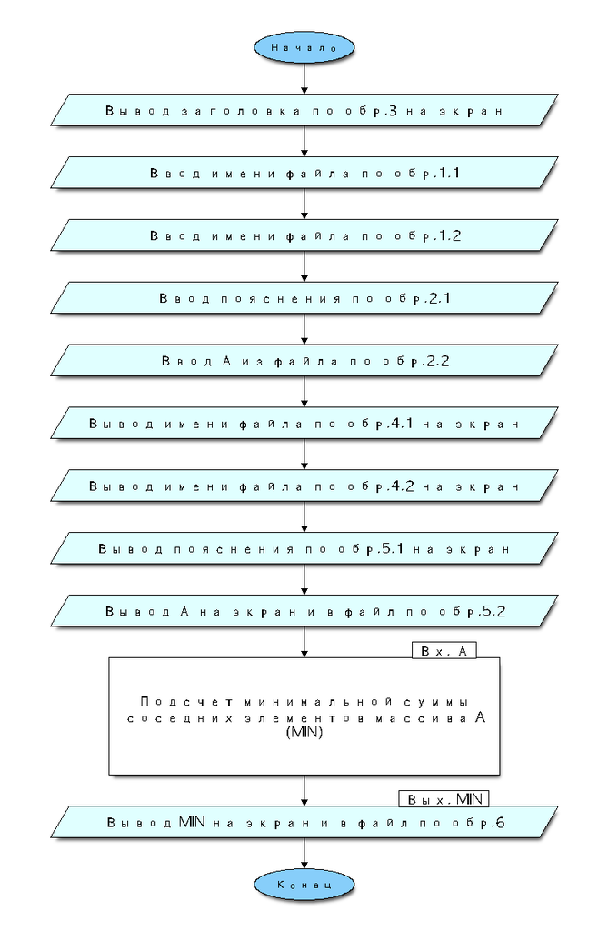

```python
from IPython.display import Image
Image("block_diagram.png")
```

### 11. Программа на *Delphi*.

**Диалоговый вариант {ввод названий файлов и данных из текстового файла, вывод на экран и в текстовый файл}**

Синтаксис:

[Pascal Tutorial](https://www.tutorialspoint.com/pascal/index.htm)

Проверить программу онлайн без установки программной среды:

[Compile and Execute Pascal Online](http://www.compileonline.com/compile_pascal_online.php)

```python
program Lab5; //сохранить как lab5.dpr (DPR – Delphi PRoject)
{$APPTYPE CONSOLE}
Uses Windows; // для русификации (сделать комментарием в онлайн-компиляторе!)

    var
        i: integer;
        PRE, MIN: real;
        fin, fout: string;
        tfin, tfout: TextFile;
        A: array of real;

    begin
        setConsoleCP(1251); // для ввода  русификация и (сделать строку комментарием в онлайн-компиляторе!)
        setConsoleOutputCP(1251); // для вывода (сделать строку комментарием в онлайн-компиляторе!)

        {A0.1, A0.3 - ввод-вывод входных данных}
        writeln('Лаб.5' :40); {вывод заголовка c переходом на следующую строку по обр.3}

        {ввод-вывод строковой переменной - имени файла с входными данными по обр.1.1, 4.1}
        writeln('Текстовый файл с элементами массива A:  ');
        readln(fin);
        writeln(fin);

        {ввод-вывод строковой переменной - имени файла с входными данными по обр.1.2, 4.2}
        writeln('Текстовый файл с элементами массива A и минимальной суммой соседних элементов: ');
        readln(fout);
        writeln(fout);

        {ввод-вывод исходного массивa A по обр.2.1, 2.2, 5.1, 5.2}
        writeln('Массив A: '); {вывод пояснения с переходом на следующую строку}

        AssignFile(tfin, fin); reset(tfin); {открыть файл для чтения}
        AssignFile(tfout, fout); rewrite(tfout); {открыть файл для записи}

        i := 1;
        MIN := 10000000000;

        while not eof(tfin) do

        begin
            SetLength(A,i);
            readln(tfin, A[i]); {ввод элемента и переход на следующую строку}
            writeln(A[i]:5:6); {вывод элемента и переход на следующую строку на экране}
            writeln(tfout, A[i]:5:6); {вывод элемента и переход на следующую строку в файле}

            MIN := -160; {заглушка для теста 1}
            // MIN := -2; {заглушка для теста 2}
            // MIN := -16; {заглушка для теста 3}
            // MIN := -953.6; {заглушка для теста 4}
            // MIN := -9000.0; {заглушка для теста 5}


            i := i + 1;
        end;

        CloseFile(tfin); {закрыть файл для чтения}

        for i:=1 to 80 do
            write('='); {отделим визуально чертой и строкой введенные и выводимые значения}
        writeln;

        writeln('Минимальная сумма соседних элементов массива A:', MIN:5:6);
        {вывод переменной и переход на следующую строку на экране по обр.6}
        writeln(tfout, MIN:5:6);
        {вывод MIN и переход на следующую строку в файле по обр.6}

        CloseFile(tfout); {закрыть файл для записи}

    end.
```

## Раскрытие абстракции А0.2

*Поскольку условие всей задачи совпадает (за исключением необходимости ввода-вывода) с условием выделенной подзадачи,*

*вместо полной спецификации с пунктами 1-11 выполнено просто дополнение к пунктам 9-11.*

### 9. Метод

Пусть

- `i` – номер текущий точки,
- `A[i]` – соответствующий элемент исходного массива A,
- `PRE` - предыдущий элемент для `A[i]`,
- `MIN` - минимальная сумма соседних элементов массива A.

Присвоим переменной `MIN` начальное значение: `MIN = 10000000000`.

Поиск минимальной суммы осуществляется с помощью цикла.

На каждом этапе сумма соседних элементов сравнивается с текущим значением переменной MIN.

Для каждого элемента, начиная со второго, предыдущий элемент сохраняется в качестве вспомогательной переменной `PRE`.

Если `A[i] + PRE < MIN`, то значение переменной `MIN` заменяется: `MIN = A[i] + PRE`.

### 10. Алгоритм

```python
%%file block_diagram2

blockdiag {
    orientation = portrait;

    class yes [thick, label = "Да", color = blue, textcolor = blue];
    class no [thick, label = "Нет", color = red, textcolor = red];
    class start_end [shape = ellipse, fontsize = 18, color = lightskyblue];
    class input_out [shape = flowchart.input, fontsize = 18, width = 400, color = lightcyan];
    class loop_in [shape = flowchart.loopin, fontsize = 18, width = 300, color = lightsteelblue];
    class loop_out [shape = flowchart.loopout, fontsize = 18, width = 300, color = lightsteelblue];
    class condition [shape = flowchart.condition, fontsize = 18, width = 400, color = lightsteelblue];
    class command_box [shape = roundedbox, fontsize = 18, width = 300];

    Начало -> "MIN := 10000000000" -> "i := 2; +1; n" ->
    "A[i] + PRE < MIN" -> "MIN := A[i] + PRE" ->
    "PRE = A[i]" -> "i = n" -> Конец;
    "A[i] + PRE < MIN" -> "PRE = A[i]" -> "i = n" -> Конец;

    Начало, Конец [class = "start_end"];
    "i := 2; +1; n" [class = "loop_in"];
    "i = n" [class = "loop_out"];
    "A[i] + PRE < MIN" [class = "condition"];
    "MIN := 10000000000", "MIN := A[i] + PRE", "PRE = A[i]" [class = "command_box"];

    "A[i] + PRE < MIN" -> "MIN := A[i] + PRE" [class = 'yes'];
    "A[i] + PRE < MIN" -> "PRE = A[i]" [class = 'no'];
}
```

```
Overwriting block_diagram2
```

```python
!blockdiag block_diagram2
```

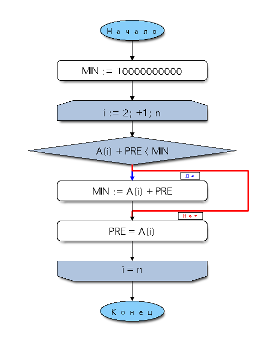

```python
Image("block_diagram2.png")
```

### 11. Программный код

```python
MIN := 10000000000;

if i > 2 then
begin
    if (A[i] + PRE < MIN) then MIN := A[i] + PRE;
    PRE: = A[i];
end;
```

## Получившаяся программа

```python
program Lab5; //сохранить как lab5.dpr (DPR – Delphi PRoject)
{$APPTYPE CONSOLE}
Uses Windows; // для русификации (сделать комментарием в онлайн-компиляторе!)

    var
        i: integer;
        PRE, MIN: real;
        fin, fout: string;
        tfin, tfout: TextFile;
        A: array of real;

    begin
        setConsoleCP(1251); // для ввода  русификация и (сделать строку комментарием в онлайн-компиляторе!)
        setConsoleOutputCP(1251); // для вывода (сделать строку комментарием в онлайн-компиляторе!)

        {A0.1, A0.2, A0.3 - ввод-вывод входных данных}
        writeln('Лаб.5' :40); {вывод заголовка c переходом на следующую строку по обр.3}

        {ввод-вывод строковой переменной - имени файла с входными данными по обр.1.1, 4.1}
        writeln('Текстовый файл с элементами массива A:  ');
        readln(fin);
        writeln(fin);

        {ввод-вывод строковой переменной - имени файла с входными данными по обр.1.2, 4.2}
        writeln('Текстовый файл с элементами массива A и минимальной суммой соседних элементов: ');
        readln(fout);
        writeln(fout);

        {ввод-вывод исходного массивa A по обр.2.1, 2.2, 5.1, 5.2}
        writeln('Массив A: '); {вывод пояснения с переходом на следующую строку}

        AssignFile(tfin, fin); reset(tfin); {открыть файл для чтения}
        AssignFile(tfout, fout); rewrite(tfout); {открыть файл для записи}

        i := 1;
        MIN := 10000000000;

        while not eof(tfin) do

        begin
            SetLength(A,i);
            readln(tfin, A[i]); {ввод элемента и переход на следующую строку}
            writeln(A[i]:5:6); {вывод элемента и переход на следующую строку на экране}
            writeln(tfout, A[i]:5:6); {вывод элемента и переход на следующую строку в файле}

            if i > 1 then
            begin
                if (A[i] + PRE < MIN) then MIN := A[i] + PRE;
                PRE: = A[i];
            end;

            i := i + 1;
        end;

        CloseFile(tfin); {закрыть файл для чтения}

        for i:=1 to 80 do
            write('='); {отделим визуально чертой и строкой введенные и выводимые значения}
        writeln;

        writeln('Минимальная сумма соседних элементов массива A:', MIN:5:6);
        {вывод переменной и переход на следующую строку на экране по обр.6}
        writeln(tfout, MIN:5:6);
        {вывод MIN и переход на следующую строку в файле по обр.6}

        CloseFile(tfout); {закрыть файл для записи}

    end.
```

*Та же программа с именами файлов, заданными в качестве параметров.*

```python
program Lab5; //сохранить как lab5.dpr (DPR – Delphi PRoject)
{$APPTYPE CONSOLE}
Uses Windows; // для русификации (сделать комментарием в онлайн-компиляторе!)

    var
        i: integer;
        PRE, MIN: real;
        fin, fout: string;
        tfin, tfout: TextFile;
        A: array of real;

    begin
        setConsoleCP(1251); // для ввода  русификация и (сделать строку комментарием в онлайн-компиляторе!)
        setConsoleOutputCP(1251); // для вывода (сделать строку комментарием в онлайн-компиляторе!)

        if (ParamCount<2) then
        begin
        writeln(‘CritError: Не заданы параметры программы’);
        readln: exit;
        end;

        {A0.1, A0.2, A0.3 - ввод-вывод входных данных}
        writeln('Лаб.5' :40); {вывод заголовка c переходом на следующую строку по обр.3}

        {ввод-вывод исходного массивa A по обр.2.1, 2.2, 5.1, 5.2}
        writeln('Массив A: '); {вывод пояснения с переходом на следующую строку}

        AssignFile(tfin, ParamStr(1)); reset(tfin); {открыть файл для чтения}
        AssignFile(tfout, ParamStr(2)); rewrite(tfout); {открыть файл для записи}

        i := 1;
        MIN := 10000000000;

        while not eof(tfin) do

        begin
            SetLength(A,i);
            readln(tfin, A[i]); {ввод элемента и переход на следующую строку}
            writeln(A[i]:5:6); {вывод элемента и переход на следующую строку на экране}
            writeln(tfout, A[i]:5:6); {вывод элемента и переход на следующую строку в файле}

            if i > 1 then
            begin
                if (A[i] + PRE < MIN) then MIN := A[i] + PRE;
                PRE: = A[i];
            end;

            i := i + 1;
        end;

        CloseFile(tfin); {закрыть файл для чтения}

        for i:=1 to 80 do
            write('='); {отделим визуально чертой и строкой введенные и выводимые значения}
        writeln;

        writeln('Минимальная сумма соседних элементов массива A:', MIN:5:6);
        {вывод переменной и переход на следующую строку на экране по обр.6}
        writeln(tfout, MIN:5:6);
        {вывод MIN и переход на следующую строку в файле по обр.6}

        CloseFile(tfout); {закрыть файл для записи}

    end.
```